# R/exams quiz

Which of the following cities are the capital of the corresponding country?

Astana (Kazakhstan)New Delhi (India)Istanbul (Turkey)Tokyo (Japan)Warsaw (Poland)

- True. Astana is the capital of Kazakhstan.
- True. New Delhi is the capital of India.
- False. The capital of Turkey is Ankara.
- True. Tokyo is the capital of Japan.
- True. Warsaw is the capital of Poland.

Which of the following cities are the capital of the corresponding country?

New Delhi (India)Istanbul (Turkey)Astana (Kazakhstan)Auckland (New Zealand)Toronto (Canada)

- True. New Delhi is the capital of India.
- False. The capital of Turkey is Ankara.
- True. Astana is the capital of Kazakhstan.
- False. The capital of New Zealand is Wellington.
- False. The capital of Canada is Ottawa.

Which of the following cities are the capital of the corresponding country?

São Paulo (Brazil)New Delhi (India)Toronto (Canada)Auckland (New Zealand)Warsaw (Poland)

- False. The capital of Brazil is Brasilia.
- True. New Delhi is the capital of India.
- False. The capital of Canada is Ottawa.
- False. The capital of New Zealand is Wellington.
- True. Warsaw is the capital of Poland.

What is the derivative of $f(x) = x^{8} e^{2.7x}$, evaluated at $x = 0.61$?

Using the product rule for $f(x) = g(x) \cdot h(x)$, where $g(x) := x^{8}$ and $h(x) := e^{2.7x}$, we obtain
$$\begin{aligned}
f'(x) & = & [g(x) \cdot h(x)]' = g'(x) \cdot h(x) +
g(x) \cdot h'(x) \\
& = & 8 x^{8 - 1} \cdot e^{2.7x} + x^{8} \cdot e^{2.7x}
\cdot 2.7 \\
& = & e^{2.7x} \cdot(8 x^7 + 2.7 x^{8}) \\
& = & e^{2.7x} \cdot x^7 \cdot (8 + 2.7x).
\end{aligned}$$
Evaluated at $x = 0.61$, the answer is
$$e^{2.7\cdot
0.61} \cdot 0.61^7 \cdot (8 + 2.7\cdot 0.61) = 1.573925.$$
Thus, rounded to two digits we have $f'(0.61) = 1.57$.

What is the derivative of $f(x) = x^{4} e^{2.3x}$, evaluated at $x = 0.6$?

Using the product rule for $f(x) = g(x) \cdot h(x)$, where $g(x) := x^{4}$ and $h(x) := e^{2.3x}$, we obtain
$$\begin{aligned}
f'(x) & = & [g(x) \cdot h(x)]' = g'(x) \cdot h(x) +
g(x) \cdot h'(x) \\
& = & 4 x^{4 - 1} \cdot e^{2.3x} + x^{4} \cdot e^{2.3x}
\cdot 2.3 \\
& = & e^{2.3x} \cdot(4 x^3 + 2.3 x^{4}) \\
& = & e^{2.3x} \cdot x^3 \cdot (4 + 2.3x).
\end{aligned}$$
Evaluated at $x = 0.6$, the answer is
$$e^{2.3\cdot
0.6} \cdot 0.6^3 \cdot (4 + 2.3\cdot 0.6) = 4.619154.$$
Thus, rounded to two digits we have $f'(0.6) = 4.62$.

What is the derivative of $f(x) = x^{6} e^{2.3x}$, evaluated at $x = 0.56$?

Using the product rule for $f(x) = g(x) \cdot h(x)$, where $g(x) := x^{6}$ and $h(x) := e^{2.3x}$, we obtain
$$\begin{aligned}
f'(x) & = & [g(x) \cdot h(x)]' = g'(x) \cdot h(x) +
g(x) \cdot h'(x) \\
& = & 6 x^{6 - 1} \cdot e^{2.3x} + x^{6} \cdot e^{2.3x}
\cdot 2.3 \\
& = & e^{2.3x} \cdot(6 x^5 + 2.3 x^{6}) \\
& = & e^{2.3x} \cdot x^5 \cdot (6 + 2.3x).
\end{aligned}$$
Evaluated at $x = 0.56$, the answer is
$$e^{2.3\cdot
0.56} \cdot 0.56^5 \cdot (6 + 2.3\cdot 0.56) = 1.45519.$$
Thus, rounded to two digits we have $f'(0.56) = 1.46$.

What is the derivative of $f(x) = x^{3} e^{2.1x}$, evaluated at $x = 0.74$?

$7.77$$15.44$$11.80$$13.76$$9.69$

Using the product rule for $f(x) = g(x) \cdot h(x)$, where $g(x) := x^{3}$ and $h(x) := e^{2.1x}$, we obtain
$$\begin{aligned}
f'(x) & = & [g(x) \cdot h(x)]' = g'(x) \cdot h(x) +
g(x) \cdot h'(x) \\
& = & 3 x^{3 - 1} \cdot e^{2.1x} + x^{3} \cdot e^{2.1x}
\cdot 2.1 \\
& = & e^{2.1x} \cdot(3 x^2 + 2.1 x^{3}) \\
& = & e^{2.1x} \cdot x^2 \cdot (3 + 2.1x).
\end{aligned}$$
Evaluated at $x = 0.74$, the answer is
$$e^{2.1\cdot
0.74} \cdot 0.74^2 \cdot (3 + 2.1\cdot 0.74) = 11.796416.$$
Thus, rounded to two digits we have $f'(0.74) = 11.80$.

- False
- False
- True
- False
- False

What is the derivative of $f(x) = x^{4} e^{2.3x}$, evaluated at $x = 0.63$?

$5.10$$4.26$$4.03$$5.80$$4.93$

Using the product rule for $f(x) = g(x) \cdot h(x)$, where $g(x) := x^{4}$ and $h(x) := e^{2.3x}$, we obtain
$$\begin{aligned}
f'(x) & = & [g(x) \cdot h(x)]' = g'(x) \cdot h(x) +
g(x) \cdot h'(x) \\
& = & 4 x^{4 - 1} \cdot e^{2.3x} + x^{4} \cdot e^{2.3x}
\cdot 2.3 \\
& = & e^{2.3x} \cdot(4 x^3 + 2.3 x^{4}) \\
& = & e^{2.3x} \cdot x^3 \cdot (4 + 2.3x).
\end{aligned}$$
Evaluated at $x = 0.63$, the answer is
$$e^{2.3\cdot
0.63} \cdot 0.63^3 \cdot (4 + 2.3\cdot 0.63) = 5.802714.$$
Thus, rounded to two digits we have $f'(0.63) = 5.80$.

- False
- False
- False
- True
- False

What is the derivative of $f(x) = x^{9} e^{4x}$, evaluated at $x = 0.73$?

$14.55$$13.46$$12.18$$17.82$$18.81$

Using the product rule for $f(x) = g(x) \cdot h(x)$, where $g(x) := x^{9}$ and $h(x) := e^{4x}$, we obtain
$$\begin{aligned}
f'(x) & = & [g(x) \cdot h(x)]' = g'(x) \cdot h(x) +
g(x) \cdot h'(x) \\
& = & 9 x^{9 - 1} \cdot e^{4x} + x^{9} \cdot e^{4x} \cdot
4 \\
& = & e^{4x} \cdot(9 x^8 + 4 x^{9}) \\
& = & e^{4x} \cdot x^8 \cdot (9 + 4x).
\end{aligned}$$
Evaluated at $x = 0.73$, the answer is
$$e^{4\cdot
0.73} \cdot 0.73^8 \cdot (9 + 4\cdot 0.73) = 17.823748.$$
Thus, rounded to two digits we have $f'(0.73) = 17.82$.

- False
- False
- False
- True
- False

Given the following information:

|  | $+$ |  | $+$ |  | = | $594$ |
| --- | --- | --- | --- | --- | --- | --- |
|  | $+$ |  | $+$ |  | = | $164$ |
|  | $+$ |  | $+$ |  | = | $560$ |

Compute:

|  | $+$ |  | $+$ |  | = | $\text{?}$ |
| --- | --- | --- | --- | --- | --- | --- |

The information provided can be interpreted as the price for three fruit baskets with different combinations of the three fruits. This corresponds to a system of linear equations where the price of the three fruits is the vector of unknowns $x$:

| $x_1 =$ |  | $x_2 =$ |  | $x_3 =$ |  |
| --- | --- | --- | --- | --- | --- |

The system of linear equations is then:
$$\begin{aligned}
\left( \begin{array}{rrr} 2 & 0 & 1 \\ 1 & 2 & 0 \\ 0
& 2 & 1 \end{array} \right) \cdot \left( \begin{array}{r} x_1 \\
x_2 \\ x_3 \end{array} \right) & = & \left( \begin{array}{r} 594
\\ 164 \\ 560 \end{array} \right)
\end{aligned}$$
This can be solved using any solution algorithm, e.g., elimination:
$$x_1 = 66, \, x_2 = 49, \, x_3 = 462.$$
Based on the three prices for the different fruits it is straightforward to compute the total price of the fourth fruit basket via:

|  | $+$ |  | $+$ |  | = |  |
| --- | --- | --- | --- | --- | --- | --- |
| $x_1$ | $+$ | $x_2$ | $+$ | $x_3$ | = |  |
| $66$ | $+$ | $49$ | $+$ | $462$ | = | $577$ |

Given the following information:

|  | $+$ |  | $+$ |  | = | $370$ |
| --- | --- | --- | --- | --- | --- | --- |
|  | $+$ |  | $+$ |  | = | $211$ |
|  | $+$ |  | $+$ |  | = | $580$ |

Compute:

|  | $+$ |  | $+$ |  | = | $\text{?}$ |
| --- | --- | --- | --- | --- | --- | --- |

The information provided can be interpreted as the price for three fruit baskets with different combinations of the three fruits. This corresponds to a system of linear equations where the price of the three fruits is the vector of unknowns $x$:

| $x_1 =$ |  | $x_2 =$ |  | $x_3 =$ |  |
| --- | --- | --- | --- | --- | --- |

The system of linear equations is then:
$$\begin{aligned}
\left( \begin{array}{rrr} 2 & 0 & 1 \\ 1 & 2 & 0 \\ 0
& 1 & 2 \end{array} \right) \cdot \left( \begin{array}{r} x_1 \\
x_2 \\ x_3 \end{array} \right) & = & \left( \begin{array}{r} 370
\\ 211 \\ 580 \end{array} \right)
\end{aligned}$$
This can be solved using any solution algorithm, e.g., elimination:
$$x_1 = 59, \, x_2 = 76, \, x_3 = 252.$$
Based on the three prices for the different fruits it is straightforward to compute the total price of the fourth fruit basket via:

|  | $+$ |  | $+$ |  | = |  |
| --- | --- | --- | --- | --- | --- | --- |
| $x_1$ | $+$ | $x_2$ | $+$ | $x_3$ | = |  |
| $59$ | $+$ | $76$ | $+$ | $252$ | = | $387$ |

Given the following information:

|  | $+$ |  | $+$ |  | = | $552$ |
| --- | --- | --- | --- | --- | --- | --- |
|  | $+$ |  | $+$ |  | = | $508$ |
|  | $+$ |  | $+$ |  | = | $810$ |

Compute:

|  | $+$ |  | $+$ |  | = | $\text{?}$ |
| --- | --- | --- | --- | --- | --- | --- |

The information provided can be interpreted as the price for three fruit baskets with different combinations of the three fruits. This corresponds to a system of linear equations where the price of the three fruits is the vector of unknowns $x$:

| $x_1 =$ |  | $x_2 =$ |  | $x_3 =$ |  |
| --- | --- | --- | --- | --- | --- |

The system of linear equations is then:
$$\begin{aligned}
\left( \begin{array}{rrr} 2 & 0 & 1 \\ 0 & 2 & 1 \\ 1
& 0 & 2 \end{array} \right) \cdot \left( \begin{array}{r} x_1 \\
x_2 \\ x_3 \end{array} \right) & = & \left( \begin{array}{r} 552
\\ 508 \\ 810 \end{array} \right)
\end{aligned}$$
This can be solved using any solution algorithm, e.g., elimination:
$$x_1 = 98, \, x_2 = 76, \, x_3 = 356.$$
Based on the three prices for the different fruits it is straightforward to compute the total price of the fourth fruit basket via:

|  | $+$ |  | $+$ |  | = |  |
| --- | --- | --- | --- | --- | --- | --- |
| $x_1$ | $+$ | $x_2$ | $+$ | $x_3$ | = |  |
| $98$ | $+$ | $76$ | $+$ | $356$ | = | $530$ |

In the following figure the distributions of a variable given by two samples (A and B) are represented by parallel boxplots. Which of the following statements are correct? *(Comment: The statements are either about correct or clearly wrong.)*

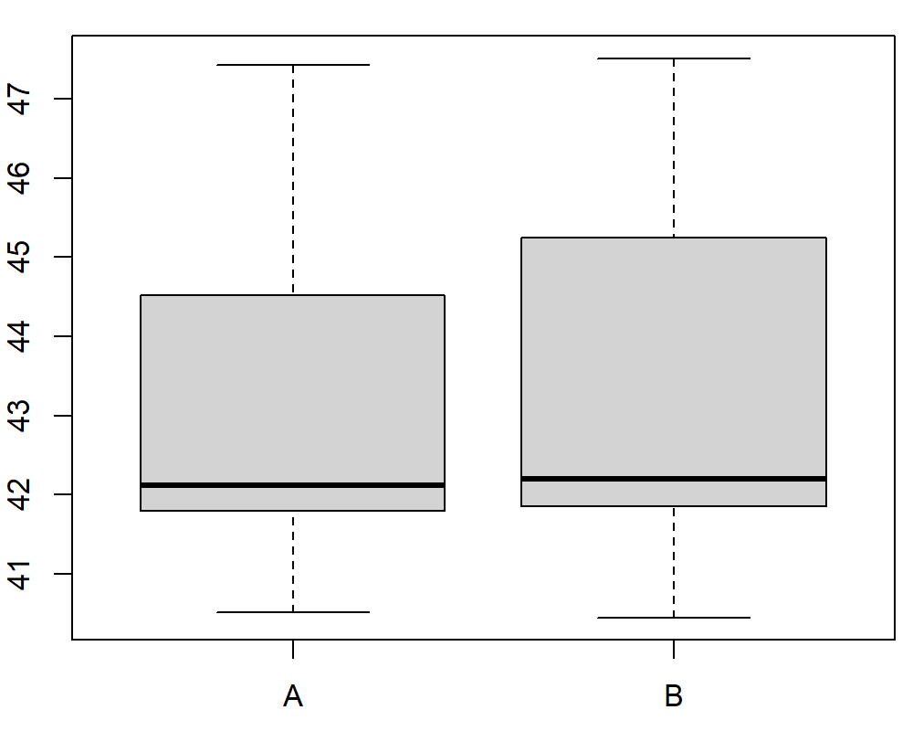

The location of both distributions is about the same.Both distributions contain no outliers.The spread in sample A is clearly bigger than in B.The skewness of both samples is similar.Distribution B is about symmetric.

- True. Both distributions have a similar location.
- True. Both distributions have no observations which deviate more than 1.5 times the interquartile range from the box.
- False. The interquartile range in sample A is *not* clearly bigger than in B.
- True. The skewness of both distributions is similar, both are right-skewed.
- False. Distribution B is right-skewed.

In the following figure the distributions of a variable given by two samples (A and B) are represented by parallel boxplots. Which of the following statements are correct? *(Comment: The statements are either about correct or clearly wrong.)*

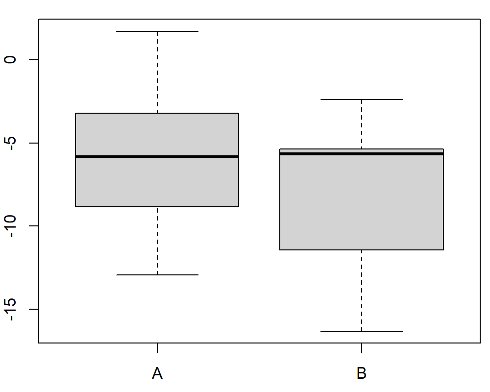

The location of both distributions is about the same.Both distributions contain no outliers.The spread in sample A is clearly bigger than in B.The skewness of both samples is similar.Distribution B is left-skewed.

- True. Both distributions have a similar location.
- True. Both distributions have no observations which deviate more than 1.5 times the interquartile range from the box.
- False. The interquartile range in sample A is *not* clearly bigger than in B.
- False. The skewness of both distributions is different. Sample A is about symmetric. Sample B is left-skewed.
- True. Distribution B is left-skewed.

In the following figure the distributions of a variable given by two samples (A and B) are represented by parallel boxplots. Which of the following statements are correct? *(Comment: The statements are either about correct or clearly wrong.)*

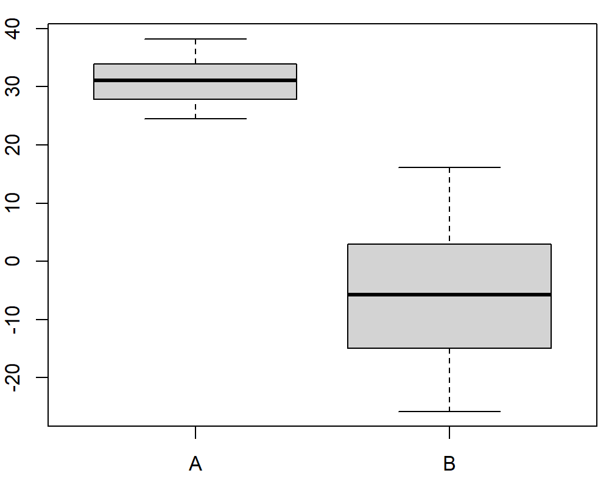

The location of both distributions is about the same.Both distributions contain no outliers.The spread in sample A is clearly bigger than in B.The skewness of both samples is similar.Distribution A is left-skewed.

- False. Distribution A has on average higher values than distribution B.
- True. Both distributions have no observations which deviate more than 1.5 times the interquartile range from the box.
- False. The interquartile range in sample A is *not* clearly bigger than in B.
- True. The skewness of both distributions is similar, both are about symmetric.
- False. Distribution A is about symmetric.

The waiting time (in minutes) at the cashier of two supermarket chains with different cashier systems is compared. The following statistical test was performed:

```
    Two Sample t-test

data:  Waiting by Supermarket
t = 4.037, df = 96, p-value = 0.9999
alternative hypothesis: true difference in means between group Sparag and group Consumo is less than 0
95 percent confidence interval:
     -Inf 4.042661
sample estimates:
 mean in group Sparag mean in group Consumo
             7.513233              4.648968
```

Which of the following statements are correct? (Significance level 5%)

The absolute value of the test statistic is larger than 1.96.A one-sided alternative was tested.The p-value is larger than 0.05.The test shows that the waiting time is longer at Sparag than at Consumo.The test shows that the waiting time is shorter at Sparag than at Consumo.

- True. The absolute value of the test statistic is equal to 4.037.
- True. The test aims at showing that the difference of means is smaller than 0.
- True. The p-value is equal to 1.
- False. The test aims at showing that the alternative that the waiting time is shorter at Sparag than at Consumo. The test result is not significant ($p \ge 0.05$).
- False. The test result ist not significant ($p \ge 0.05$).

The waiting time (in minutes) at the cashier of two supermarket chains with different cashier systems is compared. The following statistical test was performed:

```
    Two Sample t-test

data:  Waiting by Supermarket
t = -0.77172, df = 120, p-value = 0.7791
alternative hypothesis: true difference in means between group Sparag and group Consumo is greater than 0
95 percent confidence interval:
 -1.118277       Inf
sample estimates:
 mean in group Sparag mean in group Consumo
             3.441593              3.796829
```

Which of the following statements are correct? (Significance level 5%)

The absolute value of the test statistic is larger than 1.96.A one-sided alternative was tested.The p-value is larger than 0.05.The test shows that the waiting time is longer at Sparag than at Consumo.The test shows that the waiting time is shorter at Sparag than at Consumo.

- False. The absolute value of the test statistic is equal to 0.772.
- True. The test aims at showing that the difference of means is larger than 0.
- True. The p-value is equal to 0.779.
- False. The test result is not significant ($p \ge 0.05$).
- False. The test aims at showing that the waiting time at Sparag is longer than at Consumo. The test result ist not significant ($p \ge 0.05$).

The waiting time (in minutes) at the cashier of two supermarket chains with different cashier systems is compared. The following statistical test was performed:

```
    Two Sample t-test

data:  Waiting by Supermarket
t = 1.367, df = 147, p-value = 0.9131
alternative hypothesis: true difference in means between group Sparag and group Consumo is less than 0
95 percent confidence interval:
     -Inf 1.879967
sample estimates:
 mean in group Sparag mean in group Consumo
             7.649331              6.799009
```

Which of the following statements are correct? (Significance level 5%)

The absolute value of the test statistic is larger than 1.96.A one-sided alternative was tested.The p-value is larger than 0.05.The test shows that the waiting time is longer at Sparag than at Consumo.The test shows that the waiting time is shorter at Sparag than at Consumo.

- False. The absolute value of the test statistic is equal to 1.367.
- True. The test aims at showing that the difference of means is smaller than 0.
- True. The p-value is equal to 0.913.
- False. The test aims at showing that the alternative that the waiting time is shorter at Sparag than at Consumo. The test result is not significant ($p \ge 0.05$).
- False. The test result ist not significant ($p \ge 0.05$).

What is the name of the R function for extracting the fitted log-likelihood from a fitted (generalized) linear model object?

`logLik` is the R function for extracting the fitted log-likelihood from a fitted (generalized) linear model object. See `?logLik` for the corresponding manual page.

What is the name of the R function for extracting the regressor matrix from a fitted (generalized) linear model object?

`model.matrix` is the R function for extracting the regressor matrix from a fitted (generalized) linear model object. See `?model.matrix` for the corresponding manual page.

What is the name of the R function for logistic regression?

`glm` is the R function for logistic regression. See `?glm` for the corresponding manual page.

**Theory:** Consider a linear regression of `y` on `x`. It is usually estimated with which estimation technique (three-letter abbreviation)?

This estimator yields the best linear unbiased estimator (BLUE) under the assumptions of the Gauss-Markov theorem. Which of the following properties are required for the errors of the linear regression model under these assumptions?

independentzero expectationnormally distributedidentically distributedhomoscedastic

**Application:** Using the data provided in `linreg.csv` estimate a linear regression of `y` on `x`. What are the estimated parameters?

Intercept:

Slope:

In terms of significance at 5% level:

**Theory:** Linear regression models are typically estimated by ordinary least squares (OLS). The Gauss-Markov theorem establishes certain optimality properties: Namely, if the errors have expectation zero, constant variance (homoscedastic), no autocorrelation and the regressors are exogenous and not linearly dependent, the OLS estimator is the best linear unbiased estimator (BLUE).

**Application:** The estimated coefficients along with their significances are reported in the summary of the fitted regression model, showing that `x` and `y` are not significantly correlated (at 5% level).

```
Call:
lm(formula = y ~ x, data = d)

Residuals:
     Min       1Q   Median       3Q      Max
-0.61339 -0.18746 -0.01883  0.15853  0.67299

Coefficients:
            Estimate Std. Error t value Pr(>|t|)
(Intercept) 0.001211   0.027863   0.043    0.965
x           0.023606   0.050344   0.469    0.640

Residual standard error: 0.2786 on 98 degrees of freedom
Multiple R-squared:  0.002238,  Adjusted R-squared:  -0.007943
F-statistic: 0.2199 on 1 and 98 DF,  p-value: 0.6402
```

**Code:** The analysis can be replicated in R using the following code.

```
## data
d <- read.csv("linreg.csv")
## regression
m <- lm(y ~ x, data = d)
summary(m)
## visualization
plot(y ~ x, data = d)
abline(m)
```

**Theory:** Consider a linear regression of `y` on `x`. It is usually estimated with which estimation technique (three-letter abbreviation)?

This estimator yields the best linear unbiased estimator (BLUE) under the assumptions of the Gauss-Markov theorem. Which of the following properties are required for the errors of the linear regression model under these assumptions?

independentzero expectationnormally distributedidentically distributedhomoscedastic

**Application:** Using the data provided in `linreg.csv` estimate a linear regression of `y` on `x`. What are the estimated parameters?

Intercept:

Slope:

In terms of significance at 5% level:

**Theory:** Linear regression models are typically estimated by ordinary least squares (OLS). The Gauss-Markov theorem establishes certain optimality properties: Namely, if the errors have expectation zero, constant variance (homoscedastic), no autocorrelation and the regressors are exogenous and not linearly dependent, the OLS estimator is the best linear unbiased estimator (BLUE).

**Application:** The estimated coefficients along with their significances are reported in the summary of the fitted regression model, showing that `y` decreases significantly with `x` (at 5% level).

```
Call:
lm(formula = y ~ x, data = d)

Residuals:
     Min       1Q   Median       3Q      Max
-0.67491 -0.16202 -0.00232  0.17710  0.72061

Coefficients:
            Estimate Std. Error t value Pr(>|t|)
(Intercept)  0.01774    0.02701   0.657    0.513
x           -0.58299    0.04582 -12.723   <2e-16 ***
---
Signif. codes:  0 '***' 0.001 '**' 0.01 '*' 0.05 '.' 0.1 ' ' 1

Residual standard error: 0.2699 on 98 degrees of freedom
Multiple R-squared:  0.6229,    Adjusted R-squared:  0.6191
F-statistic: 161.9 on 1 and 98 DF,  p-value: < 2.2e-16
```

**Code:** The analysis can be replicated in R using the following code.

```
## data
d <- read.csv("linreg.csv")
## regression
m <- lm(y ~ x, data = d)
summary(m)
## visualization
plot(y ~ x, data = d)
abline(m)
```

**Theory:** Consider a linear regression of `y` on `x`. It is usually estimated with which estimation technique (three-letter abbreviation)?

This estimator yields the best linear unbiased estimator (BLUE) under the assumptions of the Gauss-Markov theorem. Which of the following properties are required for the errors of the linear regression model under these assumptions?

independentzero expectationnormally distributedidentically distributedhomoscedastic

**Application:** Using the data provided in `linreg.csv` estimate a linear regression of `y` on `x`. What are the estimated parameters?

Intercept:

Slope:

In terms of significance at 5% level:

**Theory:** Linear regression models are typically estimated by ordinary least squares (OLS). The Gauss-Markov theorem establishes certain optimality properties: Namely, if the errors have expectation zero, constant variance (homoscedastic), no autocorrelation and the regressors are exogenous and not linearly dependent, the OLS estimator is the best linear unbiased estimator (BLUE).

**Application:** The estimated coefficients along with their significances are reported in the summary of the fitted regression model, showing that `y` decreases significantly with `x` (at 5% level).

```
Call:
lm(formula = y ~ x, data = d)

Residuals:
     Min       1Q   Median       3Q      Max
-0.59456 -0.15746  0.04215  0.16569  0.60770

Coefficients:
             Estimate Std. Error t value Pr(>|t|)
(Intercept) -0.007246   0.024658  -0.294    0.769
x           -0.750563   0.043827 -17.125   <2e-16 ***
---
Signif. codes:  0 '***' 0.001 '**' 0.01 '*' 0.05 '.' 0.1 ' ' 1

Residual standard error: 0.2428 on 98 degrees of freedom
Multiple R-squared:  0.7495,    Adjusted R-squared:  0.747
F-statistic: 293.3 on 1 and 98 DF,  p-value: < 2.2e-16
```

**Code:** The analysis can be replicated in R using the following code.

```
## data
d <- read.csv("linreg.csv")
## regression
m <- lm(y ~ x, data = d)
summary(m)
## visualization
plot(y ~ x, data = d)
abline(m)
```

An industry-leading company seeks a qualified candidate for a management position. A management consultancy carries out an assessment center which concludes in making a positive or negative recommendation for each candidate: From previous assessments they know that of those candidates that are actually eligible for the position (event $E$) $79\%$ get a positive recommendation (event $R$). However, out of those candidates that are not eligible $68\%$ get a negative recommendation. Overall, they know that only $9\%$ of all job applicants are actually eligible.

What is the corresponding fourfold table of the joint probabilities? (Specify all entries in percent.)

|  | $R$ | $\overline{R}$ | sum |
| --- | --- | --- | --- |
| $E$ | % | % | % |
| $\overline{E}$ | % | % | % |
| sum | % | % | % |

Using the information from the text, we can directly calculate the following joint probabilities:
$$\begin{aligned}
P(E \cap R) & =
P(R | E) \cdot P(E) = 0.79 \cdot 0.09 = 0.0711 = 7.11\%\\
P(\overline{E} \cap \overline{R}) & =
P(\overline{R} | \overline{E}) \cdot P(\overline{E}) = 0.68 \cdot
0.91 = 0.6188 = 61.88\%.
\end{aligned}$$
The remaining probabilities can then be found by calculating sums and differences in the fourfold table:

|  | $R$ | $\overline{R}$ | sum |
| --- | --- | --- | --- |
| $E$ | **7.11** | *1.89* | **9.00** |
| $\overline{E}$ | *29.12* | **61.88** | *91.00* |
| sum | *36.23* | *63.77* | **100.00** |

- $P(E \cap R) = 7.11\%$
- $P(\overline{E} \cap R) = 29.12\%$
- $P(E \cap \overline{R}) = 1.89\%$
- $P(\overline{E} \cap \overline{R}) = 61.88\%$
- $P(R) = 36.23\%$
- $P(\overline{R}) = 63.77\%$
- $P(E) = 9.00\%$
- $P(\overline{E}) = 91.00\%$
- $P(\Omega) = 100.00\%$

An industry-leading company seeks a qualified candidate for a management position. A management consultancy carries out an assessment center which concludes in making a positive or negative recommendation for each candidate: From previous assessments they know that of those candidates that are actually eligible for the position (event $E$) $78\%$ get a positive recommendation (event $R$). However, out of those candidates that are not eligible $73\%$ get a negative recommendation. Overall, they know that only $10\%$ of all job applicants are actually eligible.

What is the corresponding fourfold table of the joint probabilities? (Specify all entries in percent.)

|  | $R$ | $\overline{R}$ | sum |
| --- | --- | --- | --- |
| $E$ | % | % | % |
| $\overline{E}$ | % | % | % |
| sum | % | % | % |

Using the information from the text, we can directly calculate the following joint probabilities:
$$\begin{aligned}
P(E \cap R) & =
P(R | E) \cdot P(E) = 0.78 \cdot 0.1 = 0.078 = 7.8\%\\
P(\overline{E} \cap \overline{R}) & =
P(\overline{R} | \overline{E}) \cdot P(\overline{E}) = 0.73 \cdot
0.9 = 0.657 = 65.7\%.
\end{aligned}$$
The remaining probabilities can then be found by calculating sums and differences in the fourfold table:

|  | $R$ | $\overline{R}$ | sum |
| --- | --- | --- | --- |
| $E$ | **7.80** | *2.20* | **10.00** |
| $\overline{E}$ | *24.30* | **65.70** | *90.00* |
| sum | *32.10* | *67.90* | **100.00** |

- $P(E \cap R) = 7.8\%$
- $P(\overline{E} \cap R) = 24.3\%$
- $P(E \cap \overline{R}) = 2.2\%$
- $P(\overline{E} \cap \overline{R}) = 65.7\%$
- $P(R) = 32.1\%$
- $P(\overline{R}) = 67.9\%$
- $P(E) = 10.0\%$
- $P(\overline{E}) = 90.0\%$
- $P(\Omega) = 100.0\%$

An industry-leading company seeks a qualified candidate for a management position. A management consultancy carries out an assessment center which concludes in making a positive or negative recommendation for each candidate: From previous assessments they know that of those candidates that are actually eligible for the position (event $E$) $79\%$ get a positive recommendation (event $R$). However, out of those candidates that are not eligible $73\%$ get a negative recommendation. Overall, they know that only $7\%$ of all job applicants are actually eligible.

What is the corresponding fourfold table of the joint probabilities? (Specify all entries in percent.)

|  | $R$ | $\overline{R}$ | sum |
| --- | --- | --- | --- |
| $E$ | % | % | % |
| $\overline{E}$ | % | % | % |
| sum | % | % | % |

Using the information from the text, we can directly calculate the following joint probabilities:
$$\begin{aligned}
P(E \cap R) & =
P(R | E) \cdot P(E) = 0.79 \cdot 0.07 = 0.0553 = 5.53\%\\
P(\overline{E} \cap \overline{R}) & =
P(\overline{R} | \overline{E}) \cdot P(\overline{E}) = 0.73 \cdot
0.93 = 0.6789 = 67.89\%.
\end{aligned}$$
The remaining probabilities can then be found by calculating sums and differences in the fourfold table:

|  | $R$ | $\overline{R}$ | sum |
| --- | --- | --- | --- |
| $E$ | **5.53** | *1.47* | **7.00** |
| $\overline{E}$ | *25.11* | **67.89** | *93.00* |
| sum | *30.64* | *69.36* | **100.00** |

- $P(E \cap R) = 5.53\%$
- $P(\overline{E} \cap R) = 25.11\%$
- $P(E \cap \overline{R}) = 1.47\%$
- $P(\overline{E} \cap \overline{R}) = 67.89\%$
- $P(R) = 30.64\%$
- $P(\overline{R}) = 69.36\%$
- $P(E) = 7.00\%$
- $P(\overline{E}) = 93.00\%$
- $P(\Omega) = 100.00\%$